# Segundo Trabajo TAE

### (g)

Fit a support vector classifier to the data with X1 and X2 as predictors. Obtain a class prediction for each training observation. Plot the observations, colored according to the predicted class labels.

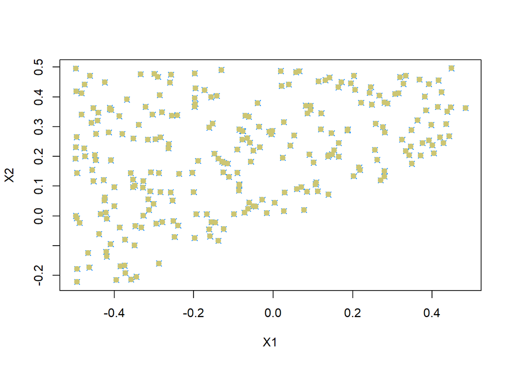

```r
library(e1071)
svm.fit = svm(as.factor(y) ~ ., data = datos, kernel = "linear", cost = 1)
svm.pred = predict(svm.fit, datos)
datos.pos = datos[svm.pred == 1, ]
datos.neg = datos[svm.pred == 0, ]
plot(datos.pos$x1, datos.pos$x2, col = "dodgerblue1", xlab = "X1", ylab = "X2", pch = 4)
points(datos.pos$x1, datos.pos$x2, col = "khaki3", pch = 19)
```

### (h)

Fit a SVM using a non-linear kernel to the data. Obtain a class prediction for each training observation. Plot the observations, colored according to the predicted class labels.

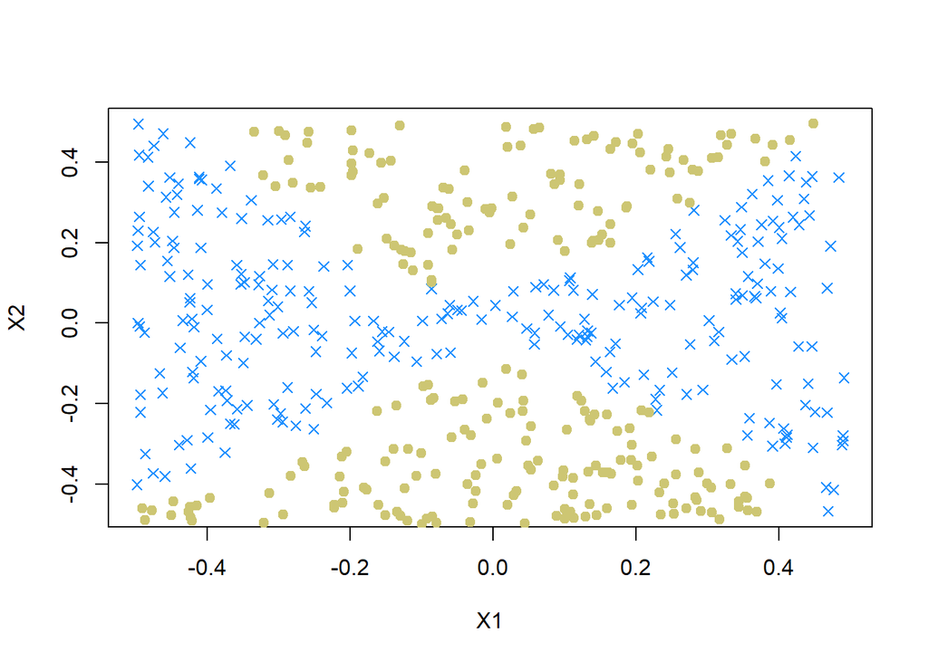

```r
svm.fit = svm(as.factor(y) ~ ., datos, gamma = 1)
svm.pred = predict(svm.fit, datos)
datos.pos = datos[svm.pred == 1, ]
datos.neg = datos[svm.pred == 0, ]
plot(datos.pos$x1, datos.pos$x2, col = "dodgerblue1", xlab = "X1", ylab = "X2", pch = 4)
points(datos.neg$x1, datos.neg$x2, col = "khaki3", pch = 19)
```

Este modelo SVM con el núcleo no lineal sí es capaz de identificar la no linealidad entre las clases, lo que significa que hace una clara clasificación de las diferentes clases a pesar de que no haya una separación lineal entre ellas.

### (i)

Comment on your results.

Efectivamente una regresión logística lineal o un SVM de kernel lineal presentan grandes problemas a la hora de clasificar datos que presentan relaciones no lineales. En cambio, una regresión logística de parámetros no lineales y un kernel radial si permiten clasificar muy bien este tipo de datos. Pero entre estos dos últimos métodos el que brinda mejores resultados y es mucho más fácil de manipular es el de SVM con kernel no lineal, ya que solo depende de un buen ajuste para el parámetro gamma.

## Ejercicio 6

At the end of Section 9.6.1, it is claimed that in the case of data that is just barely linearly separable, a support vector classifier with a small value of cost that misclassifies a couple of training observations may perform better on test data than one with a huge value of cost that does not misclassify any training observations. You will now investigate this claim.

### (a)

Generate two-class data with p = 2 in such a way that the classes are just barely linearly separable.

```r
library(e1071)
library(ggplot2)
library(dplyr)
```

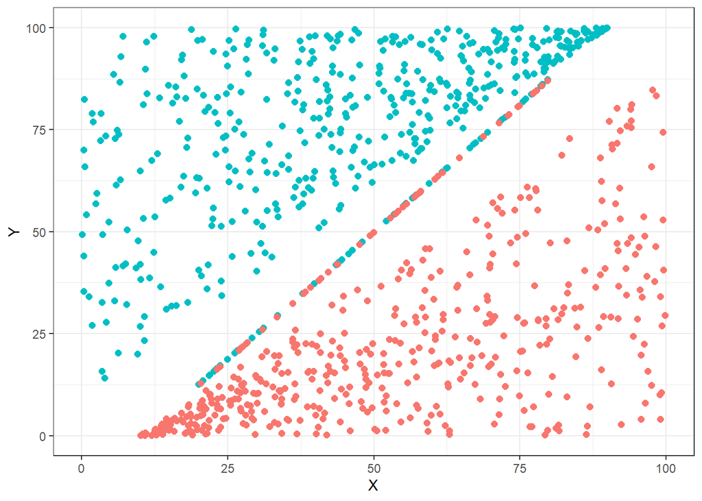

```r
set.seed(2520)

x.pos = runif(450, 0, 90)
y.pos = runif(450, x.pos + 10, 100)
x.pos.ruido = runif(50, 20, 80)
y.pos.ruido = 5/4 * (x.pos.ruido - 10) + 0.1

x.neg = runif(450, 10, 100)
y.neg = runif(450, 0, x.neg - 10)
x.neg.ruido = runif(50, 20, 80)
y.neg.ruido = 5/4 * (x.neg.ruido - 10) - 0.1

x = c(x.pos, x.pos.ruido, x.neg, x.neg.ruido)
y = c(y.pos, y.pos.ruido, y.neg, y.neg.ruido)

positivos = seq(1, 500)
z = rep(-1, 1000)
z[positivos] = 1

datos = data.frame(X = x, Y = y, z = as.factor(z))

ggplot(data = datos, aes(x = X, y = Y, color = as.factor(z))) +
  geom_point(size = 2) +
  theme_bw() +
  theme(legend.position = "none")
```

### (b)

Compute the cross-validation error rates for support vector classifiers with a range of cost values. How many training errors are misclassified for each value of cost considered, and how does this relate to the cross-validation errors obtained?

```r
set.seed(325)
model.tuning <- tune(svm, z ~ ., data = datos,
               kernel = "linear",
               ranges = list(cost = c(0.01, 0.1, 1, 5, 10, 50, 100, 500, 1000,5000)))

summary(model.tuning)
```

```
##
## Parameter tuning of 'svm':
##
## - sampling method: 10-fold cross validation
##
## - best parameters:
##  cost
##  5000
##
## - best performance: 0
##
## - Detailed performance results:
##     cost error dispersion
## 1  1e-02 0.072 0.02740641
## 2  1e-01 0.051 0.01728840
## 3  1e+00 0.053 0.01828782
## 4  5e+00 0.053 0.01828782
## 5  1e+01 0.053 0.01828782
## 6  5e+01 0.051 0.01595131
## 7  1e+02 0.049 0.01523884
## 8  5e+02 0.043 0.02110819
## 9  1e+03 0.016 0.01349897
## 10 5e+03 0.000 0.00000000
```

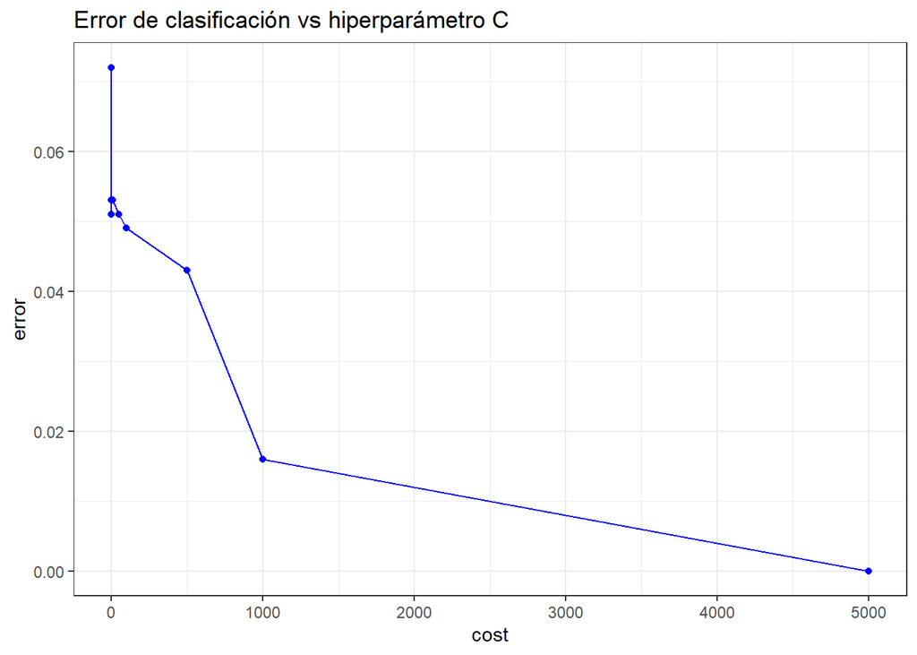

```r
ggplot(data = model.tuning$performances, aes(x = cost, y = error)) +
  geom_line(color= "blue") +
  geom_point(color="blue") +
  labs(title = "Error de clasificación vs hiperparámetro C") +
  theme_bw()
```

```r
paste("El mejor modelo es el siguiente:")
```

```
## [1] "El mejor modelo es el siguiente:"
```

```r
model.tuning$best.model
```

```
##
## Call:
## best.tune(method = svm, train.x = z ~ ., data = datos, ranges = list(cost = c(0.01,
##     0.1, 1, 5, 10, 50, 100, 500, 1000, 5000)), kernel = "linear")
##
##
## Parameters:
##    SVM-Type:  C-classification
##  SVM-Kernel:  linear
##        cost:  5000
##
## Number of Support Vectors:  49
```

Se puede ver como a medida que aumenta el valor del parámetro costo, el error de clasificación de entrenamiento disminuye. Siendo mínimo para el valor de c = 5000. El mejor modelo para estos datos con los parámetros evaluados es entonces cuando c = 5000 el cual según los resultados usa 49 vectores de soporte.

### (c)

Generate an appropriate test data set, and compute the test errors corresponding to each of the values of cost considered. Which value of cost leads to the fewest test errors, and how does this compare to the values of cost that yield the fewest training errors and the fewest cross-validation errors?

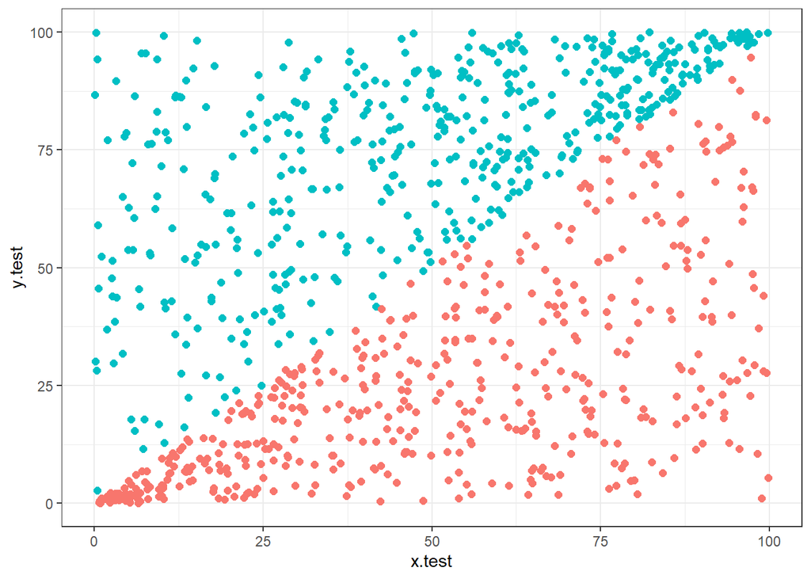

```r
set.seed(2321)
x.test = runif(1000, 0, 100)
positivos = sample(1000, 500)
y.test = rep(NA, 1000)
for (i in positivos) {
    y.test[i] = runif(1, x.test[i], 100)
}
for (i in setdiff(1:1000, positivos)) {
    y.test[i] = runif(1, 0, x.test[i])
}

z.test = rep(-1, 1000)
z.test[positivos] = 1
datos.test = data.frame(X = x.test, Y = y.test, z = as.factor(z.test))

ggplot(data = datos.test, aes(x = x.test, y = y.test, color = as.factor(z.test))) +
  geom_point(size = 2) +
  theme_bw() +
  theme(legend.position = "none")
```

Ahora si se ve una clara separacion lineal entre este conjunto de datos.

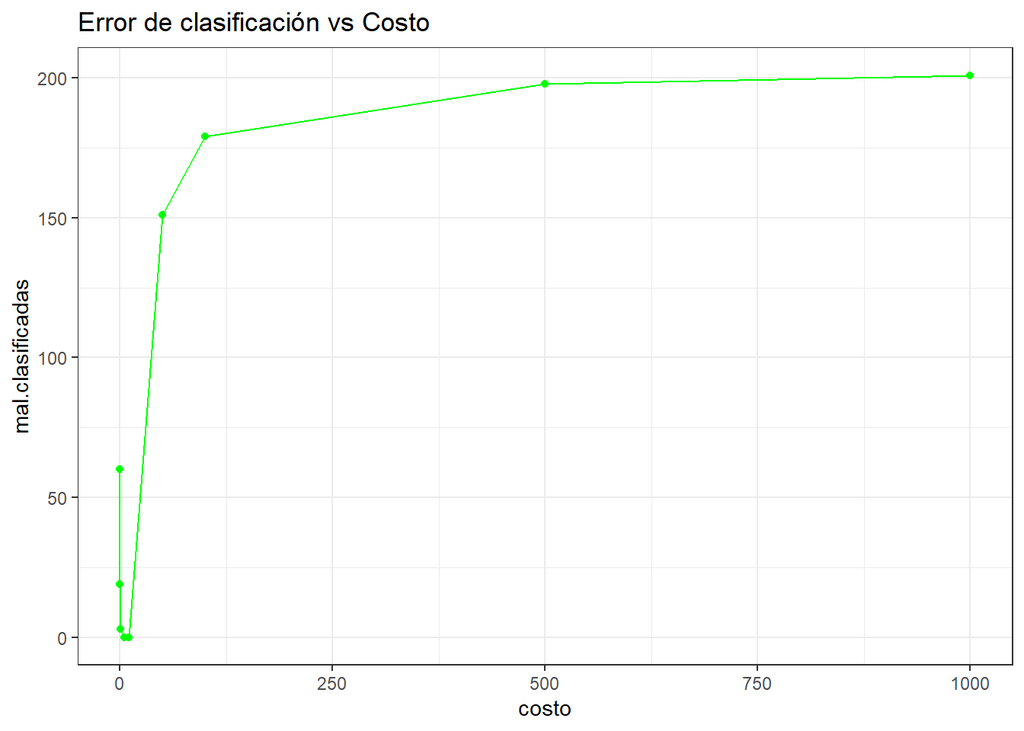

```r
costos = c(0.01, 0.1, 1, 5, 10, 50, 100, 500,1000)
mal.clasificadas = rep(NA, length(costos))
errores.test = rep(NA, length(costos))
for (i in 1:length(costos)) {
    svm.fit = svm(z ~ ., data = datos, kernel = "linear", cost = costos[i])
    svm.predict = predict(svm.fit, datos.test)
    mal.clasificadas[i] = sum(svm.predict !=datos.test$z)
    errores.test[i] = mean(svm.predict != datos.test$z)*100
}
resultado = data.frame(costo = costos, mal_clasificadas = mal.clasificadas, porcentaje_error = errores.test)

ggplot(data = resultado, aes(x = costo, y = mal.clasificadas)) +
  geom_line(color= "green") +
  geom_point(color="green") +
  labs(title = "Error de clasificación vs Costo") +
  theme_bw()
```

```r
resultado
```

```
##   costo mal_clasificadas porcentaje_error
## 1 1e-02               60              6.0
## 2 1e-01               19              1.9
## 3 1e+00                3              0.3
## 4 5e+00                0              0.0
## 5 1e+01                0              0.0
## 6 5e+01              151             15.1
## 7 1e+02              179             17.9
## 8 5e+02              198             19.8
## 9 1e+03              201             20.1
```

Se puede apreciar que en realidad no se necesita un valor del parámetro C tan alto para entrenar el modelo y hacer la respectiva evaluación con los datos de prueba. Basta solamente un valor de C = 5 o C = 10 en el entrenamiento del modelo para ver como este clasifica correctamente todos los datos de prueba.

### (d)

Discuss your results.

Lo que ha ocurrido con este ejercicio en primera instancia, cuando se entrenó el modelo con valores altos para el parámetro Costo, es que como bien se sabe al ser este mayor, mayor es el margen del hiperplano creado por lo que dejará pasar más puntos ruidosos que intentará clasificar, por tanto a medida que crecía el valor de C lo que pasaba era que el modelo se ajustaba más a los datos, es decir, se presentaba overfitting. Por tanto un margen relativamente bueno que no deja pasar tantos puntos ruidosos, que no genera overfitting y que hace excelentes predicciones sobre los datos de prueba es el que se genera con un modelo usando C = 5. A continuación se presenta gráficamente el mejor hiperplano para este problema.

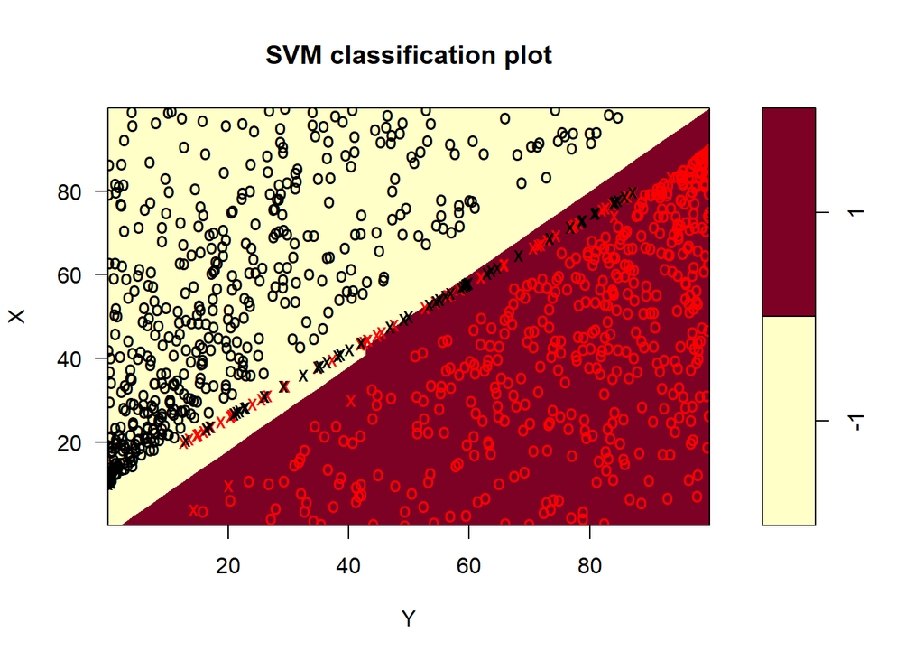

```r
#PRIMERA FORMA DE GRAFICAR EL MODELO FORMA BASICA
svm.5 = svm(z ~ ., data = datos, kernel = "linear", cost = 5)
plot(svm.5, datos)
```

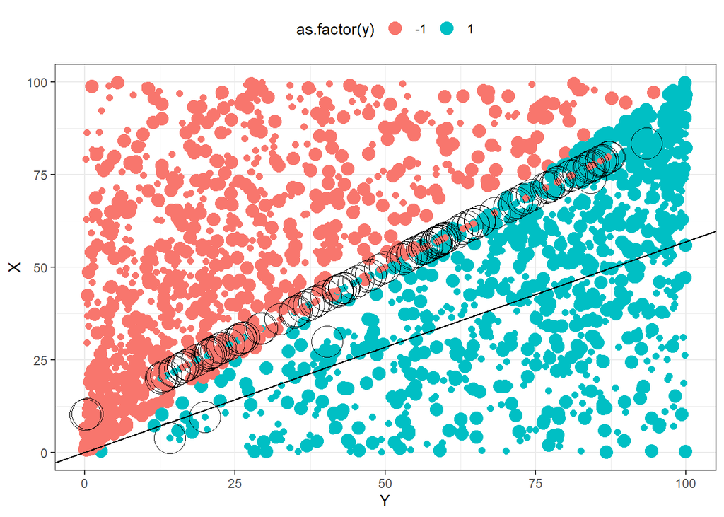

```r
#SEGUNDA FORMA DE GRAFICAR EL MODELO
predicciones = predict(svm.5, datos.test)

# Se almacenan los puntos predichos para dar color a las regiones
color_regiones = data.frame(datos.test, y = predicciones)
beta = drop(t(svm.5$coefs) %*% as.matrix(datos[,c("X","Y")])[svm.5$index,])
beta0 = svm.5$rho

# Representación de las 2 regiones empleando los puntos y coloreándolos
ggplot() +
  geom_point(data = color_regiones, aes(x = Y, y = X, color = as.factor(y)),size = 4) +
  # Se añaden las observaciones iniciales
  geom_point(data = datos, aes(x = Y, y = X, color = as.factor(z)),size = 2) +
  # Se identifican aquellas observaciones que son vectores soporte del modelo
  geom_point(data = datos[svm.5$index, ],
             aes(x = Y, y = X, color = as.factor(z)),
             shape = 21, colour = "black",
             size = 10) +
  # Se añaden las rectas del hiperplano y los márgenes
  geom_abline(intercept = beta0/beta[2], slope = -beta[1]/beta[2]) +
  geom_abline(intercept = (beta0 - 1)/beta[2], slope = -beta[1]/beta[2],
              linetype = "dashed") +
  geom_abline(intercept = (beta0 + 1)/beta[2], slope = -beta[1]/beta[2],
              linetype = "dashed") +
  theme_bw() +
  theme(legend.position = "top")
```

## Ejercicio 7

In this problem, you will use support vector approaches in order to predict whether a given car gets high or low gas mileage based on the Auto data set.

### (a)

Create a binary variable that takes on a 1 for cars with gas mileage above the median, and a 0 for cars with gas mileage below the median.

```r
library(ISLR)
library(e1071)
mediana = median(Auto$mpg)
nivel.gasol = ifelse(Auto$mpg > mediana, 1, 0)
Auto$nivel.gasol = as.factor(nivel.gasol)
```

### (b)

Fit a support vector classifier to the data with various values of cost, in order to predict whether a car gets high or low gas mileage. Report the cross-validation errors associated with different values of this parameter. Comment on your results.

```r
set.seed(2000)
tuning.lineal = tune(svm, nivel.gasol ~ ., data = Auto, kernel = "linear",
              ranges = list(cost = c(0.001, 0.01,0.1, 1, 5, 10, 20, 30)),
              scale = TRUE)

summary(tuning.lineal)
```

```
##
## Parameter tuning of 'svm':
##
## - sampling method: 10-fold cross validation
##
## - best parameters:
##  cost
##  0.01
##
## - best performance: 0
##
## - Detailed performance results:
##    cost      error dispersion
## 1 1e-03 0.06384615 0.06080042
## 2 1e-02 0.00000000 0.00000000
## 3 1e-01 0.00000000 0.00000000
## 4 1e+00 0.00000000 0.00000000
## 5 5e+00 0.00000000 0.00000000
## 6 1e+01 0.00000000 0.00000000
## 7 2e+01 0.00000000 0.00000000
## 8 3e+01 0.00000000 0.00000000
```

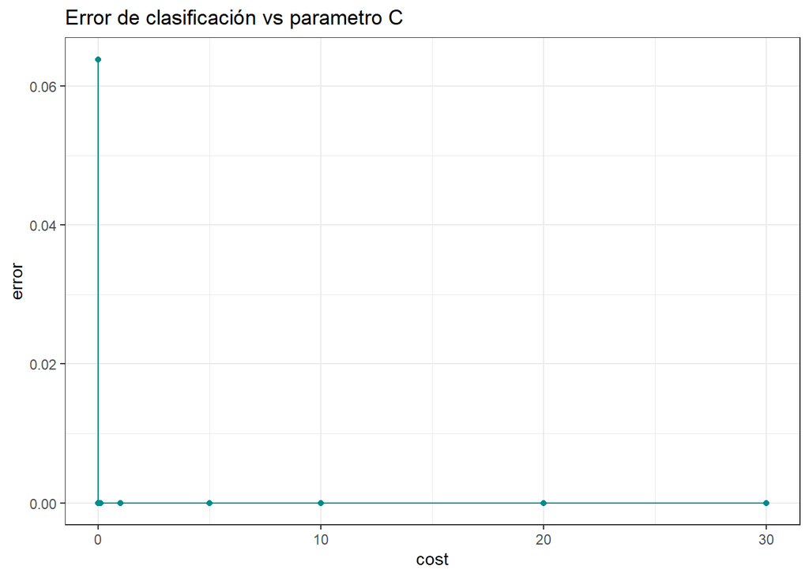

```r
ggplot(data = tuning.lineal$performances, aes(x = cost, y = error)) +
  geom_line(color= "cyan4") +
  geom_point(color="cyan4") +
  labs(title = "Error de clasificación vs parametro C") +
  theme_bw()
```

```r
paste("EL MEJOR MODELO ESTÁ CONFIGURADO DE LA SIGUIENTE FORMA:")
```

```
## [1] "EL MEJOR MODELO ESTÁ CONFIGURADO DE LA SIGUIENTE FORMA:"
```

```r
summary(tuning.lineal$best.model)
```

```
##
## Call:
## best.tune(method = svm, train.x = nivel.gasol ~ ., data = Auto, ranges = list(cost = c(0.001,
##     0.01, 0.1, 1, 5, 10, 20, 30)), kernel = "linear", scale = TRUE)
##
##
## Parameters:
##    SVM-Type:  C-classification
##  SVM-Kernel:  linear
##        cost:  0.01
##
## Number of Support Vectors:  90
##
##  ( 45 45 )
##
##
## Number of Classes:  2
##
## Levels:
##  0 1
```

### (c)

Now repeat (b), this time using SVMs with radial and polynomial basis kernels, with different values of gamma and degree and cost. Comment on your results.

```r
set.seed(500)
tuning.poli = tune(svm, nivel.gasol ~ ., data = Auto, kernel = "polynomial",
                    ranges = list(cost = c(0.1, 1, 5, 10, 15, 20),
                    degree = c(2, 3, 4)),
                    scale = TRUE)
summary(tuning.poli)
```

```
##
## Parameter tuning of 'svm':
##
## - sampling method: 10-fold cross validation
##
## - best parameters:
##  cost degree
##    20      2
##
## - best performance: 0.4396154
##
## - Detailed performance results:
##    cost degree     error dispersion
## 1   0.1      2 0.5585897 0.04751014
## 2   1.0      2 0.5585897 0.04751014
## 3   5.0      2 0.5585897 0.04751014
## 4  10.0      2 0.5124359 0.08995051
## 5  15.0      2 0.4921154 0.07626023
## 6  20.0      2 0.4396154 0.11223698
## 7   0.1      3 0.5585897 0.04751014
## 8   1.0      3 0.5585897 0.04751014
## 9   5.0      3 0.5585897 0.04751014
## 10 10.0      3 0.5585897 0.04751014
## 11 15.0      3 0.5585897 0.04751014
## 12 20.0      3 0.5585897 0.04751014
## 13  0.1      4 0.5585897 0.04751014
## 14  1.0      4 0.5585897 0.04751014
## 15  5.0      4 0.5585897 0.04751014
## 16 10.0      4 0.5585897 0.04751014
## 17 15.0      4 0.5585897 0.04751014
## 18 20.0      4 0.5585897 0.04751014
```

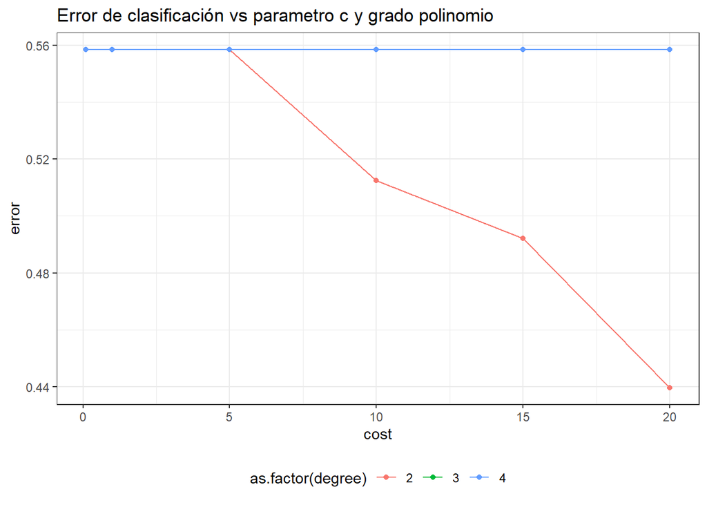

```r
ggplot(data = tuning.poli$performances, aes(x = cost, y = error, col = as.factor(degree))) +
  geom_line() +
  geom_point() +
  labs(title = "Error de clasificación vs parametro c y grado polinomio") +
  theme(plot.title = element_text(hjust = 0.5)) +
  theme_bw() + theme(legend.position = "bottom")
```

```r
paste("EL MEJOR MODELO ESTÁ CONFIGURADO DE LA SIGUIENTE FORMA:")
```

```
## [1] "EL MEJOR MODELO ESTÁ CONFIGURADO DE LA SIGUIENTE FORMA:"
```

```r
summary(tuning.poli$best.model)
```

```
##
## Call:
## best.tune(method = svm, train.x = nivel.gasol ~ ., data = Auto, ranges = list(cost = c(0.1,
##     1, 5, 10, 15, 20), degree = c(2, 3, 4)), kernel = "polynomial",
##     scale = TRUE)
##
##
## Parameters:
##    SVM-Type:  C-classification
##  SVM-Kernel:  polynomial
##        cost:  20
##      degree:  2
##      coef.0:  0
##
## Number of Support Vectors:  384
##
##  ( 192 192 )
##
##
## Number of Classes:  2
##
## Levels:
##  0 1
```

```r
set.seed(600)
tuning.radial = tune(svm, nivel.gasol ~ ., data = Auto, kernel = "radial",
                    ranges = list(cost = c(0.1, 1, 5, 10,20),
                    gamma = c(0.01, 0.1, 1, 5, 10, 20,50)))
summary(tuning.radial)
```

```
##
## Parameter tuning of 'svm':
##
## - sampling method: 10-fold cross validation
##
## - best parameters:
##  cost gamma
##     1  0.01
##
## - best performance: 0
##
## - Detailed performance results:
##    cost gamma       error  dispersion
## 1   0.1  0.01 0.020448718 0.026468917
## 2   1.0  0.01 0.000000000 0.000000000
```

[output cut: 33 more lines]

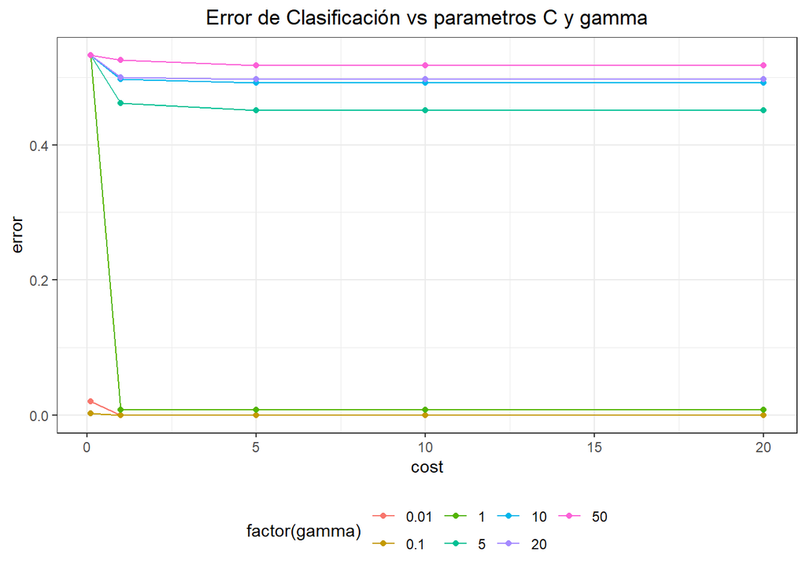

```r
ggplot(data = tuning.radial$performances, aes(x = cost, y = error, color = factor(gamma))) +
  geom_line() +
  geom_point() +
  labs(title = "Error de Clasificación vs parametros C y gamma") +
  theme_bw() +
  theme(plot.title = element_text(hjust = 0.5)) +
  theme(legend.position = "bottom")
```

```r
paste("EL MEJOR MODELO ESTÁ CONFIGURADO DE LA SIGUIENTE FORMA:")
```

```
## [1] "EL MEJOR MODELO ESTÁ CONFIGURADO DE LA SIGUIENTE FORMA:"
```

```r
summary(tuning.radial$best.model)
```

```
##
## Call:
## best.tune(method = svm, train.x = nivel.gasol ~ ., data = Auto, ranges = list(cost = c(0.1,
##     1, 5, 10, 20), gamma = c(0.01, 0.1, 1, 5, 10, 20, 50)), kernel = "radial")
##
##
## Parameters:
##    SVM-Type:  C-classification
##  SVM-Kernel:  radial
##        cost:  1
##
## Number of Support Vectors:  69
##
##  ( 36 33 )
##
##
## Number of Classes:  2
##
## Levels:
##  0 1
```

### (d)

Make some plots to back up your assertions in (b) and (c).

*Hint: In the lab, we used the plot() function for svm objects only in cases with p = 2. When p > 2, you can use the plot() function to create plots displaying pairs of variables at a time. Essentially, instead of typing*

> plot(svmfit , dat)

*where svmfit contains your fitted model and dat is a data frame containing your data, you can type*

> plot(svmfit , dat , x1∼x4)

*in order to plot just the first and fourth variables. However, you must replace x1 and x4 with the correct variable names. To find out more, type ?plot.svm.*

ALGUNAS GRAFICAS CON EL MEJOR MODELO SVM LINEAL

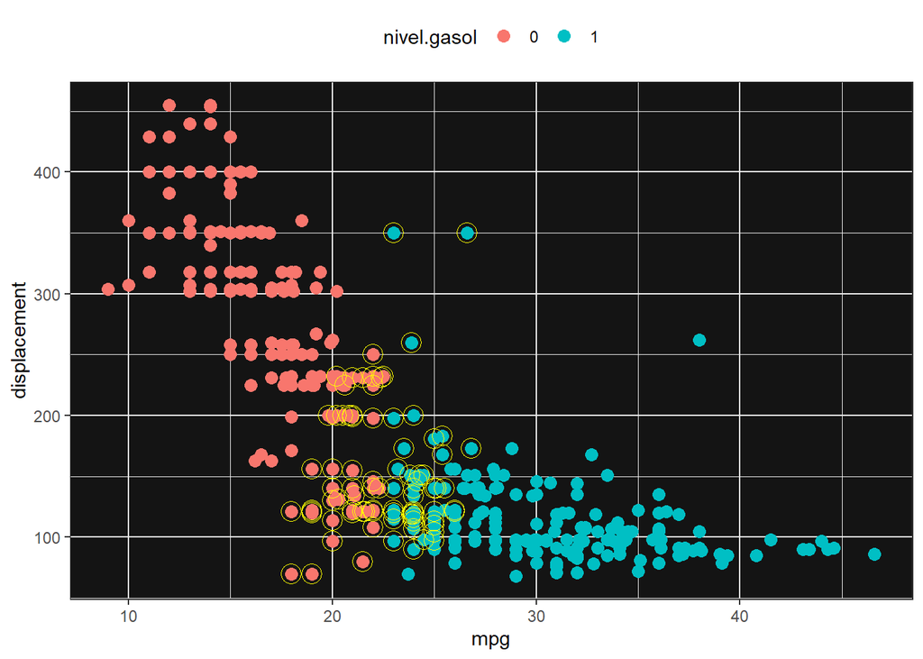

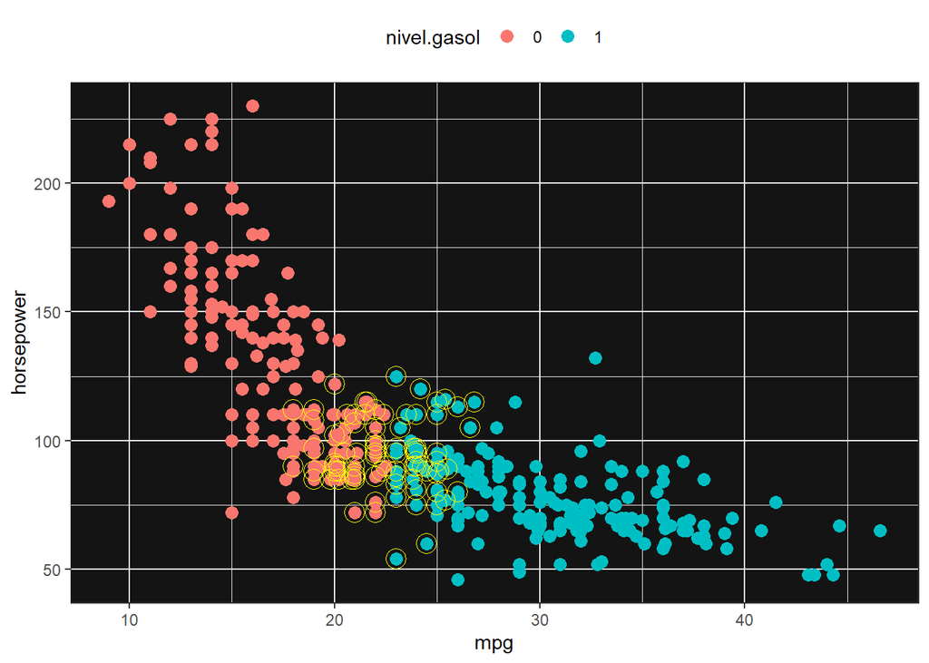

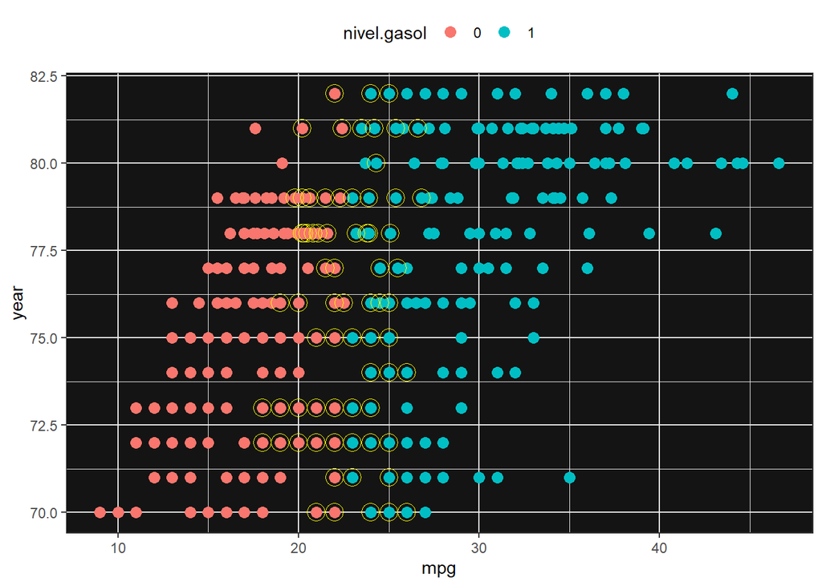

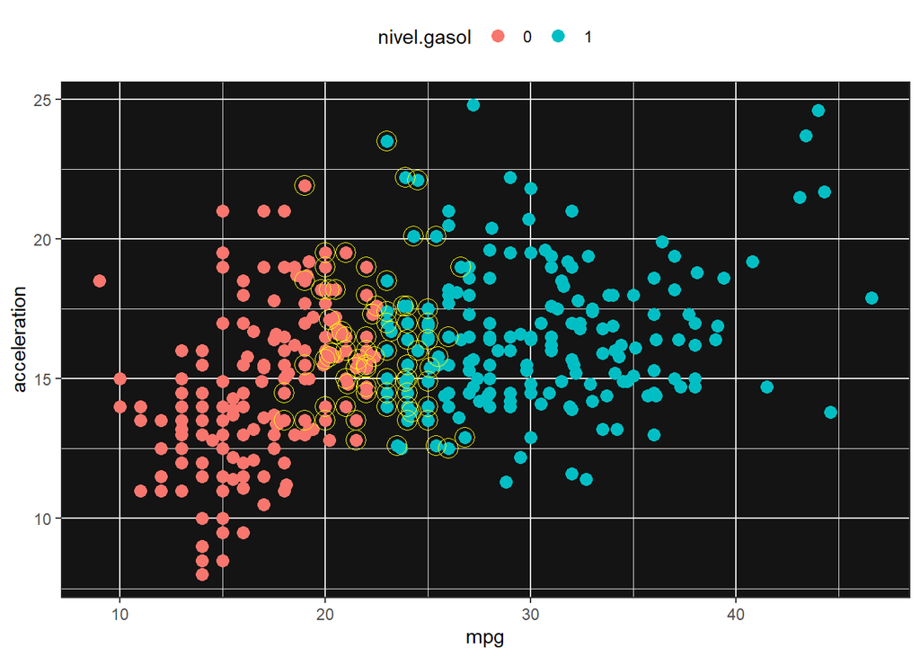

ALGUNAS GRAFICAS CON EL MEJOR MODELO SVM POLINOMIAL

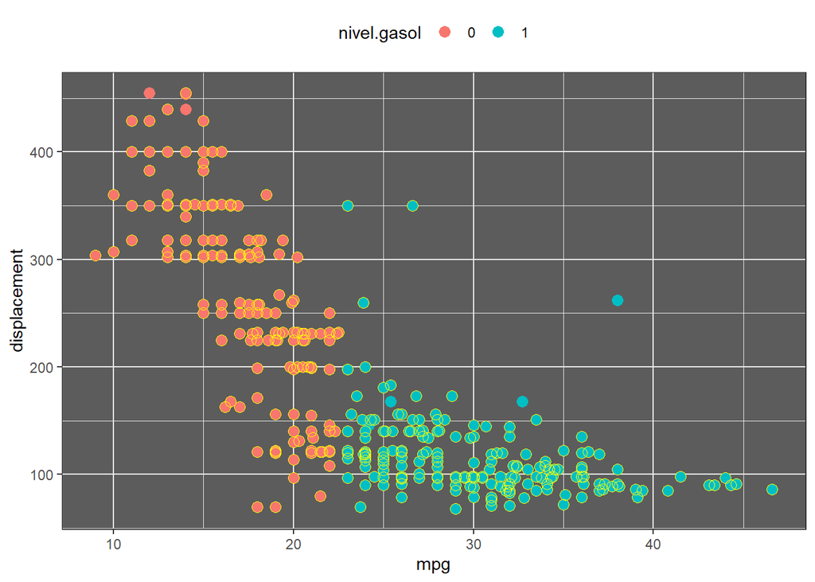

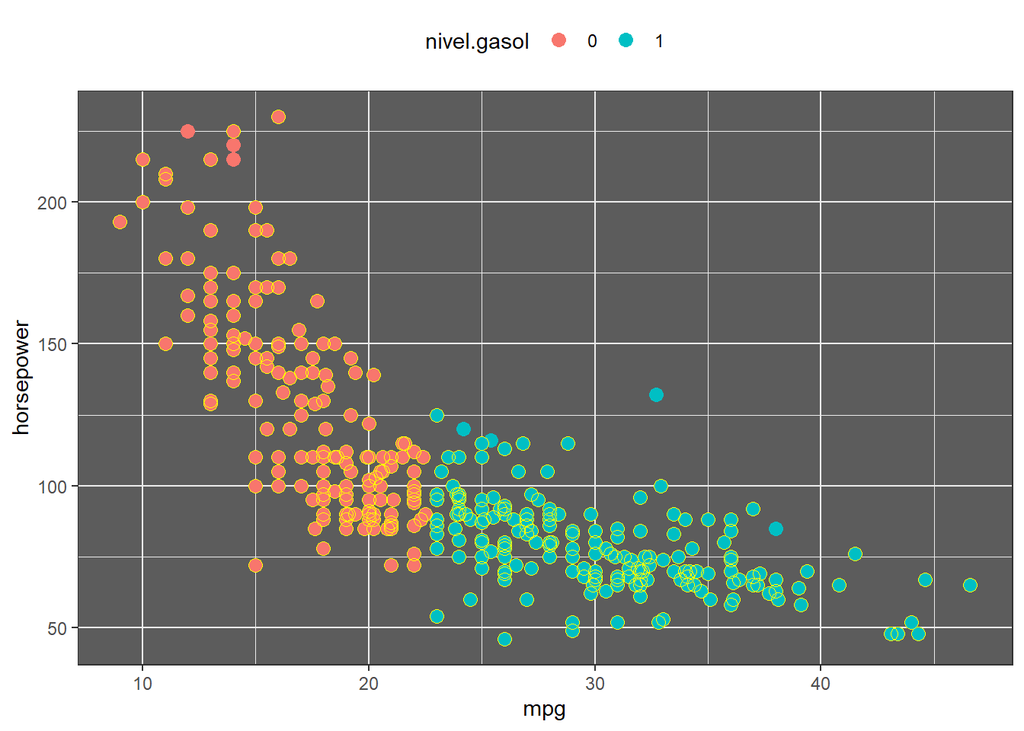

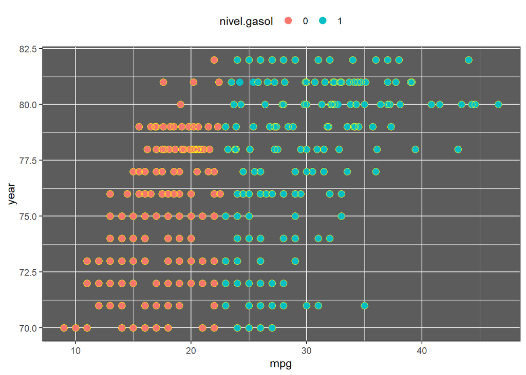

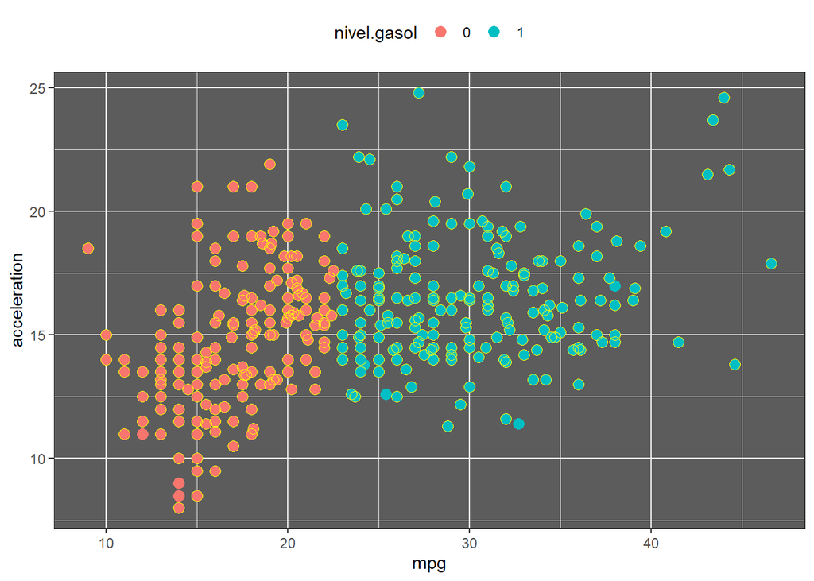

ALGUNAS GRAFICAS CON EL MEJOR MODELO SVM RADIAL

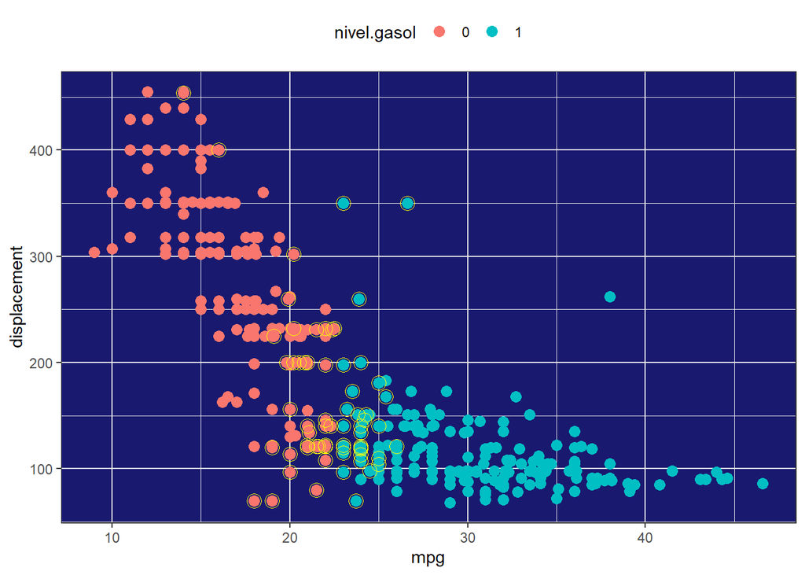

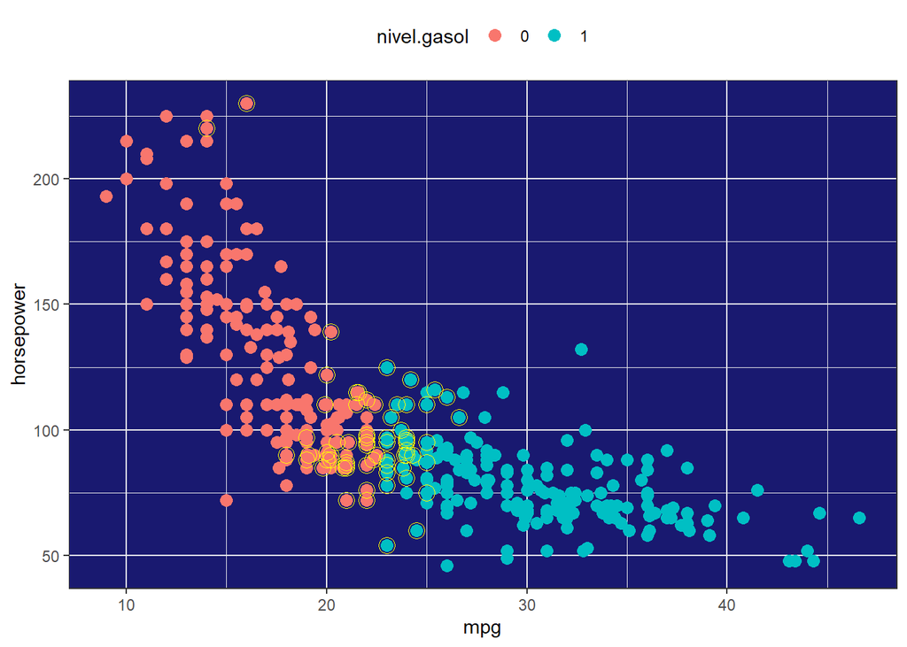

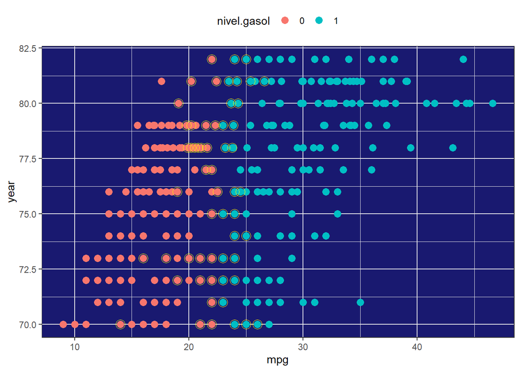

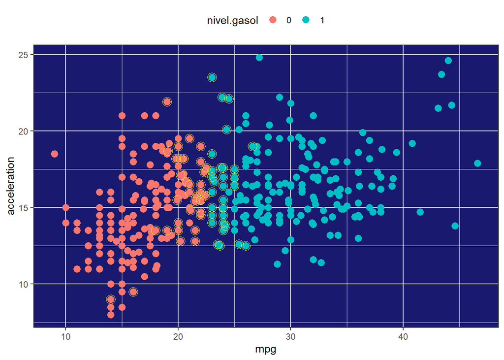

## Ejercicio 8

This problem involves the OJ data set which is part of the ISLR package.

### (a)

Create a training set containing a random sample of 800 observations, and a test set containing the remaining observations.

```r
library(ISLR)
library(e1071)
library(ggplot2)
set.seed(700)
train = sample(nrow(OJ), 800)
OJ.train = OJ[train, ]
OJ.test = OJ[-train, ]
```

### (b)

Fit a support vector classifier to the training data using cost=0.01, with Purchase as the response and the other variables as predictors. Use the summary() function to produce summary statistics, and describe the results obtained.

```r
svm.lineal = svm(Purchase ~ ., kernel = "linear", data = OJ.train, cost = 0.01)
summary(svm.lineal)
```

```
##
## Call:
## svm(formula = Purchase ~ ., data = OJ.train, kernel = "linear", cost = 0.01)
##
##
## Parameters:
##    SVM-Type:  C-classification
##  SVM-Kernel:  linear
##        cost:  0.01
##
## Number of Support Vectors:  444
##
##  ( 223 221 )
##
##
## Number of Classes:  2
##
## Levels:
##  CH MM
```

El SVM lineal creado usa 444 de las 800 observaciones como vectores de soporte, 223 son de la clase CH y 221 son de la clase MM, es una distribución bastante equitativa.

### (c)

What are the training and test error rates?

```r
predic.train = predict(svm.lineal, OJ.train)
table(predicho = predic.train, real = OJ.train$Purchase)
```

```
##         real
## predicho  CH  MM
##       CH 427  73
##       MM  57 243
```

```r
error.train = round(mean(predic.train != OJ.train$Purchase),4)
paste("EL TRAIN ERROR ES DE:", error.train)
```

```
## [1] "EL TRAIN ERROR ES DE: 0.1625"
```

```r
predic.test = predict(svm.lineal, OJ.test)
table(predicho = predic.test, OJ.test$Purchase)
```

```
##
## predicho  CH  MM
##       CH 153  31
##       MM  16  70
```

```r
error.test = round(mean(predic.test != OJ.test$Purchase),4)
paste("EL TEST ERROR ES DE:", error.test)
```

```
## [1] "EL TEST ERROR ES DE: 0.1741"
```

### (d)

Use the tune() function to select an optimal cost. Consider values in the range 0.01 to 10.

```r
set.seed(200)
model.tuning = tune(svm, Purchase ~ ., data = OJ.train, kernel = "linear",
                    ranges = list(cost = 10^seq(-2, 1, by = 0.25)))
summary(model.tuning)
```

```
##
## Parameter tuning of 'svm':
##
## - sampling method: 10-fold cross validation
##
## - best parameters:
##      cost
##  5.623413
##
## - best performance: 0.1625
##
## - Detailed performance results:
##           cost   error dispersion
## 1   0.01000000 0.17375 0.02239947
## 2   0.01778279 0.17000 0.02713137
## 3   0.03162278 0.16750 0.02371708
## 4   0.05623413 0.17125 0.02949223
## 5   0.10000000 0.17375 0.03143004
## 6   0.17782794 0.17375 0.03143004
## 7   0.31622777 0.17500 0.02946278
## 8   0.56234133 0.17625 0.03030516
## 9   1.00000000 0.17375 0.03458584
## 10  1.77827941 0.17250 0.03374743
## 11  3.16227766 0.16500 0.03216710
## 12  5.62341325 0.16250 0.03280837
## 13 10.00000000 0.16375 0.03197764
```

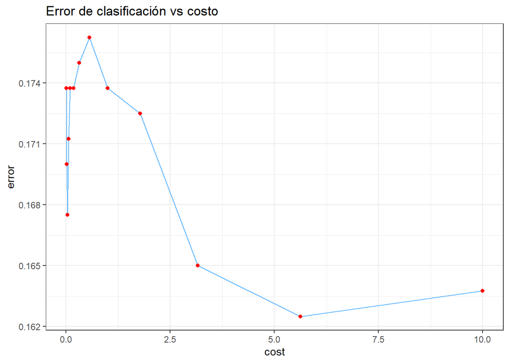

```r
ggplot(data = model.tuning$performances, aes(x = cost, y = error)) +
  geom_line(color = "steelblue1") +
  geom_point(color = "red") +
  labs(title = "Error de clasificación vs costo") +
  theme(plot.title = element_text(hjust = 0.5)) +
  theme_bw() + theme(legend.position = "none")
```

### (e)

Compute the training and test error rates using this new value for cost.

Al optimizar el parametro se genera de forma automatica un modelo con los mejores parametros. El cual se encuentra resumido a continuación.

```r
model.tuning$best.model
```

```
##
## Call:
## best.tune(method = svm, train.x = Purchase ~ ., data = OJ.train,
##     ranges = list(cost = 10^seq(-2, 1, by = 0.25)), kernel = "linear")
##
##
## Parameters:
##    SVM-Type:  C-classification
##  SVM-Kernel:  linear
##        cost:  5.623413
##
## Number of Support Vectors:  331
```

```r
mejor.svm.lineal = svm(Purchase ~ ., kernel = "linear", data = OJ.train,
                       cost =model.tuning$best.parameters$cost)
predic.train = predict(mejor.svm.lineal, OJ.train)
table(predicho = predic.train, real = OJ.train$Purchase)
```

```
##         real
## predicho  CH  MM
##       CH 429  69
##       MM  55 247
```

```r
error.train = round(mean(predic.train != OJ.train$Purchase),4)
paste("EL TRAIN ERROR CON EL MEJOR SVM LINEAL ES DE:", error.train)
```

```
## [1] "EL TRAIN ERROR CON EL MEJOR SVM LINEAL ES DE: 0.155"
```

```r
predic.test = predict(mejor.svm.lineal, OJ.test)
table(predicho = predic.test, real = OJ.test$Purchase)
```

```
##         real
## predicho  CH  MM
##       CH 151  30
##       MM  18  71
```

```r
error.test = round(mean(predic.test != OJ.test$Purchase),4)
paste("EL TEST ERROR CON EL MEJOR SVM LINEAL ES DE:", error.test)
```

```
## [1] "EL TEST ERROR CON EL MEJOR SVM LINEAL ES DE: 0.1778"
```

### (f)

Repeat parts (b) through (e) using a support vector machine with a radial kernel. Use the default value for gamma.

```r
set.seed(600)
svm.radial = svm(Purchase ~ ., data = OJ.train, kernel = "radial")
summary(svm.radial)
```

```
##
## Call:
## svm(formula = Purchase ~ ., data = OJ.train, kernel = "radial")
##
##
## Parameters:
##    SVM-Type:  C-classification
##  SVM-Kernel:  radial
##        cost:  1
##
## Number of Support Vectors:  368
##
##  ( 184 184 )
##
##
## Number of Classes:  2
##
## Levels:
##  CH MM
```

Usando el valor por defecto para el kernel radial se crea un SVM que usa 368 observaciones como vectores de soporte, usa de a 184 para cada clase.

```r
predic.train = predict(svm.radial, OJ.train)
table(predicho = predic.train, real = OJ.train$Purchase)
```

```
##         real
## predicho  CH  MM
##       CH 442  77
##       MM  42 239
```

```r
error.train = round(mean(predic.train != OJ.train$Purchase),4)
paste("EL TRAIN ERROR ES DE:", error.train)
```

```
## [1] "EL TRAIN ERROR ES DE: 0.1488"
```

```r
predic.test = predict(svm.radial, OJ.test)
table(predicho = predic.test, real = OJ.test$Purchase)
```

```
##         real
## predicho  CH  MM
##       CH 154  36
##       MM  15  65
```

```r
error.test = round(mean(predic.test != OJ.test$Purchase),4)
paste("EL TEST ERROR ES DE:", error.test)
```

```
## [1] "EL TEST ERROR ES DE: 0.1889"
```

```r
set.seed(400)
tuning.radial = tune(svm, Purchase ~ ., data = OJ.train, kernel = "radial",
                     ranges = list(cost = 10^seq(-2, 1, by = 0.25)))
summary(tuning.radial)
```

```
##
## Parameter tuning of 'svm':
##
## - sampling method: 10-fold cross validation
##
## - best parameters:
##       cost
##  0.5623413
##
## - best performance: 0.16875
##
## - Detailed performance results:
##           cost   error dispersion
## 1   0.01000000 0.39500 0.04758034
## 2   0.01778279 0.39500 0.04758034
## 3   0.03162278 0.33875 0.07440738
## 4   0.05623413 0.20500 0.03872983
## 5   0.10000000 0.17875 0.04528076
## 6   0.17782794 0.17250 0.03763863
## 7   0.31622777 0.17000 0.03593976
## 8   0.56234133 0.16875 0.04050463
## 9   1.00000000 0.16875 0.04259385
## 10  1.77827941 0.17000 0.04377975
## 11  3.16227766 0.17125 0.04641674
## 12  5.62341325 0.17125 0.03821086
## 13 10.00000000 0.17500 0.03864008
```

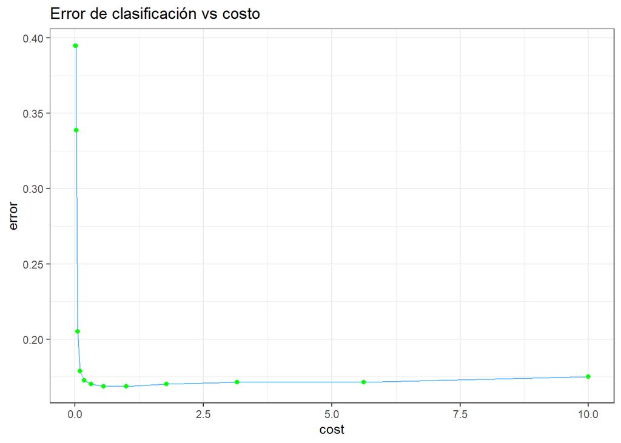

```r
ggplot(data = tuning.radial$performances, aes(x = cost, y = error)) +
  geom_line(color = "steelblue1") +
  geom_point(color = "green") +
  labs(title = "Error de clasificación vs costo") +
  theme(plot.title = element_text(hjust = 0.5)) +
  theme_bw() + theme(legend.position = "none")
```

```r
mejor.svm.radial = svm(Purchase ~ ., data = OJ.train, kernel = "radial",
                       cost = tuning.radial$best.parameters$cost)

predic.train = predict(mejor.svm.radial, OJ.train)
table(predicho = predic.train, real = OJ.train$Purchase)
```

```
##         real
## predicho  CH  MM
##       CH 442  79
##       MM  42 237
```

```r
error.train = round(mean(predic.train != OJ.train$Purchase),4)
paste("EL TRAIN ERROR CON EL MEJOR SVM RADIAL ES DE:", error.train)
```

```
## [1] "EL TRAIN ERROR CON EL MEJOR SVM RADIAL ES DE: 0.1512"
```

```r
predic.test = predict(mejor.svm.radial, OJ.test)
table(predicho = predic.test, real = OJ.test$Purchase)
```

```
##         real
## predicho  CH  MM
##       CH 153  37
##       MM  16  64
```

```r
error.test = round(mean(predic.test != OJ.test$Purchase),4)
paste("EL TEST ERROR CON EL MEJOR SVM RADIAL ES DE:", error.test)
```

```
## [1] "EL TEST ERROR CON EL MEJOR SVM RADIAL ES DE: 0.1963"
```

### (g)

Repeat parts (b) through (e) using a support vector machine with a polynomial kernel. Set degree=2.

```r
set.seed(1100)
svm.poly = svm(Purchase ~ ., data = OJ.train, kernel = "poly", degree = 2)
summary(svm.poly)
```

```
##
## Call:
## svm(formula = Purchase ~ ., data = OJ.train, kernel = "poly", degree = 2)
##
##
## Parameters:
##    SVM-Type:  C-classification
##  SVM-Kernel:  polynomial
##        cost:  1
##      degree:  2
##      coef.0:  0
##
## Number of Support Vectors:  449
##
##  ( 228 221 )
##
##
## Number of Classes:  2
##
## Levels:
##  CH MM
```

El SVM polinomial inicial con grado = 2 usa 449 vectores de soporte distribuidos en 228 para la clase CH y 221 para la clase MM.

```r
predic.train = predict(svm.poly, OJ.train)
table(predicho = predic.train, real = OJ.train$Purchase)
```

```
##         real
## predicho  CH  MM
##       CH 450 107
##       MM  34 209
```

```r
error.train = round(mean(predic.train != OJ.train$Purchase),4)
paste("EL TRAIN ERROR ES DE:", error.train)
```

```
## [1] "EL TRAIN ERROR ES DE: 0.1762"
```

```r
predic.test = predict(svm.poly, OJ.test)
table(predicho = predic.test, real = OJ.test$Purchase)
```

```
##         real
## predicho  CH  MM
##       CH 154  41
##       MM  15  60
```

```r
error.test = round(mean(predic.test != OJ.test$Purchase),4)
paste("EL TEST ERROR ES DE:", error.test)
```

```
## [1] "EL TEST ERROR ES DE: 0.2074"
```

```r
set.seed(100)
tuning.poli = tune(svm, Purchase ~ ., data = OJ.train, kernel = "poly", degree = 2,
    ranges = list(cost = 10^seq(-2, 1, by = 0.25)))
summary(tuning.poli)
```

```
##
## Parameter tuning of 'svm':
##
## - sampling method: 10-fold cross validation
##
## - best parameters:
##      cost
##  5.623413
##
## - best performance: 0.1775
##
## - Detailed performance results:
##           cost   error dispersion
## 1   0.01000000 0.39500 0.06952218
## 2   0.01778279 0.36875 0.05899918
## 3   0.03162278 0.35875 0.05714565
## 4   0.05623413 0.33375 0.05744865
## 5   0.10000000 0.31875 0.04611655
## 6   0.17782794 0.24750 0.04851976
## 7   0.31622777 0.20375 0.05466120
## 8   0.56234133 0.19875 0.05382908
## 9   1.00000000 0.19500 0.05439056
## 10  1.77827941 0.18000 0.06015027
## 11  3.16227766 0.18125 0.05781015
## 12  5.62341325 0.17750 0.05062114
## 13 10.00000000 0.17875 0.05138701
```

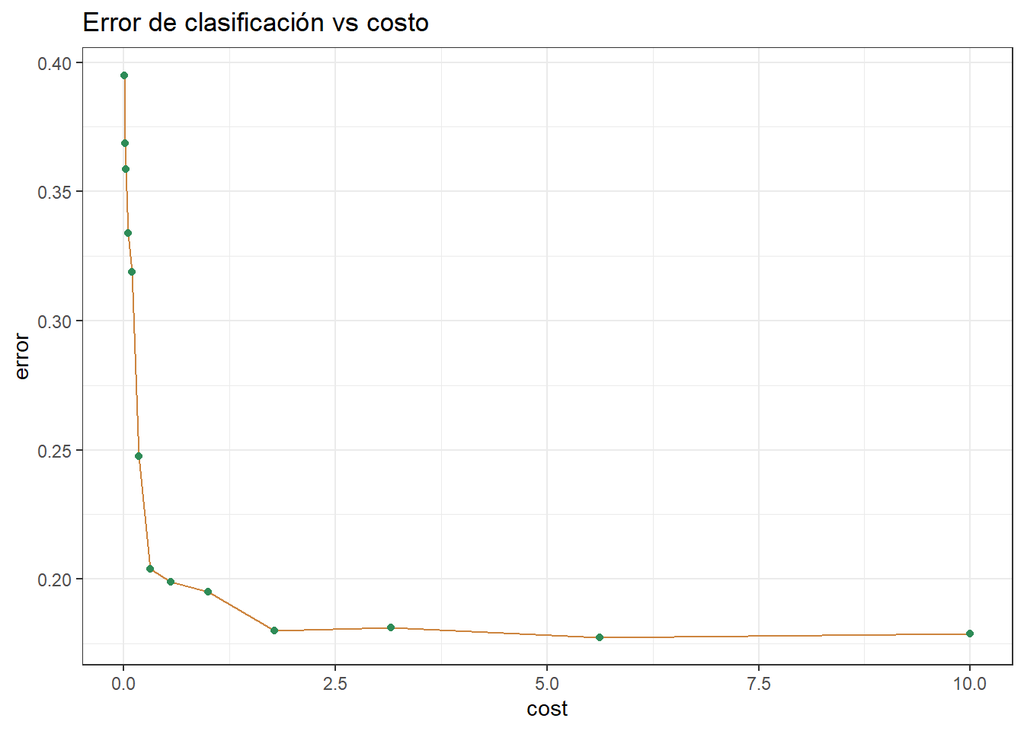

```r
ggplot(data = tuning.poli$performances, aes(x = cost, y = error)) +
  geom_line(color = "tan3") +
  geom_point(color = "seagreen") +
  labs(title = "Error de clasificación vs costo") +
  theme(plot.title = element_text(hjust = 0.5)) +
  theme_bw() + theme(legend.position = "none")
```

```r
mejor.svm.poly = svm(Purchase ~ ., data = OJ.train, kernel = "poly", degree = 2,
                     cost = tuning.poli$best.parameters$cost)

predic.train = predict(mejor.svm.poly, OJ.train)
table(predicho = predic.train, real = OJ.train$Purchase)
```

```
##         real
## predicho  CH  MM
##       CH 446  77
##       MM  38 239
```

```r
error.train = round(mean(predic.train != OJ.train$Purchase),4)
paste("EL TRAIN ERROR CON EL MEJOR SVM POLINOMIAL ES DE:", error.train)
```

```
## [1] "EL TRAIN ERROR CON EL MEJOR SVM POLINOMIAL ES DE: 0.1438"
```

```r
predic.test = predict(mejor.svm.poly, OJ.test)
table(predicho = predic.test, real = OJ.test$Purchase)
```

```
##         real
## predicho  CH  MM
##       CH 154  37
##       MM  15  64
```

```r
error.test = round(mean(predic.test != OJ.test$Purchase),4)
paste("EL TEST ERROR CON EL MEJOR SVM POLINOMIAL ES DE:", error.test)
```

```
## [1] "EL TEST ERROR CON EL MEJOR SVM POLINOMIAL ES DE: 0.1926"
```

### (h)

Overall, which approach seems to give the best results on this data?

Con los modelos calibrados se ve que para este conjunto de datos quien presenta un mejor rendimiento para los datos de entrenamiento es el SVM polinomial. Sin embargo quien presenta mejor rendimiento con los datos de prueba es el SVM lineal.